# Modelling cycling rates to 2050

15/09/2014

## What could happen if we get serious about cycling

Current expectations:

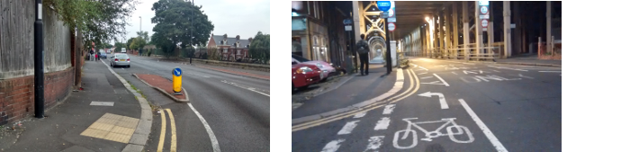

## The kind of thing that's needed:

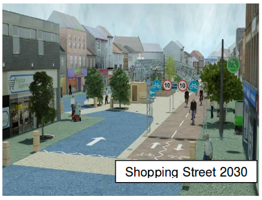

## Policy context

- GBC report published spring 2013 with ambitious plan for cycling
- Since then there has been little commitment to cycling from main political parties of DfT
- Parliamentary Question tabled by CTC revealed complete lack of ambition for cycling the the National Transport Model
- DfT is currently updating its handling of cycling, but it will likely fall short of the vision needed to transform cycling in UK
- This research provides detail in space, time and demographics of how the shift to cycling could look in the coming years

## Context: in graphics

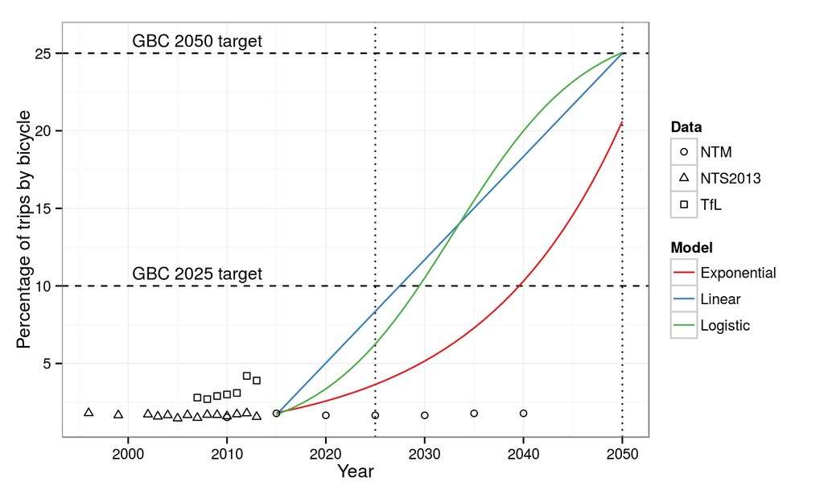

## The approach

- Occam's razor approach used: start simple, add complexity (distance, mode, spatial and temporal variables)
- Avoids distinction between 'cyclists' and 'non-cyclists'
- Scenarios are 'top down' overall but assignment 'bottom up'
- Focus on stages
- Outputs: increase in km cycled per person by place and time; concomitant decrease in driving

## Modelling stages

1. Scenario development - overall % stages by bicycle nationwide
2. Allocation of stages to individuals depending on distance, mode and socio-demographic variables
3. Disaggregate by Local Authority
4. Ouput results into format useable by health and transport economists to estimate monetary savings

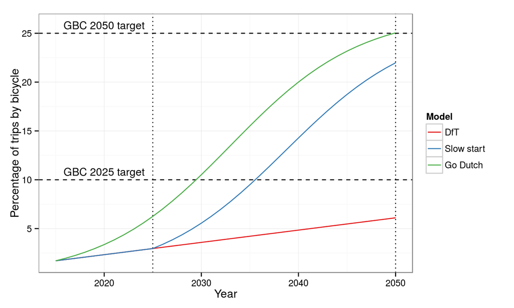

## NTS: foundation of future scenarios

- Travel in the UK's National Travel Survey (NTS) is measured in stages and trips.
- Data in the NTS is contains information on households, vehicles, individuals, trips and stages.
- The NTS is the basis of the future scenarios produced by the Department for Transport (DfT) and in this study.
- We therefore begin with current data from the NTS and move forward
- Sample of individuals taken from NTS forms basis of weekly activity patterns, to be translated into health impacts

## National trip rates and modelling change

- Stages are the atomic elements of the NTS (7.8 vs 9.1 miles)
- A logical basis against which to model modal shift.
- DfT projects **doubling** in the number of stages by bicycle by 2025.
- Assume (for now) that stage distances and total number remain constant

## Proportion of trips made by bicycle

- Currently cycling accounts for just under 2% of all stages, commuting taking up disproportionate share of cycle trips:

|  | Shopping | Commuting | Visiting.friends | Other | Percent |
| --- | --- | --- | --- | --- | --- |
| All_modes | 18.6 | 17.4 | 16.2 | 47.8 | 100.0 |
| Bicycle | 12.0 | 32.9 | 13.6 | 41.5 | 1.7 |
| Bus | 26.4 | 20.6 | 13.9 | 39.0 | 7.5 |
| Car/van driver | 19.7 | 22.0 | 13.4 | 44.9 | 46.4 |
| Car/van passenger | 17.8 | 6.8 | 23.5 | 51.9 | 25.9 |
| Walk | 16.8 | 11.9 | 13.4 | 57.9 | 12.6 |

## Distance distribution of stages

- Network distance and mode are the most important parameters for determining probability of shifting mode

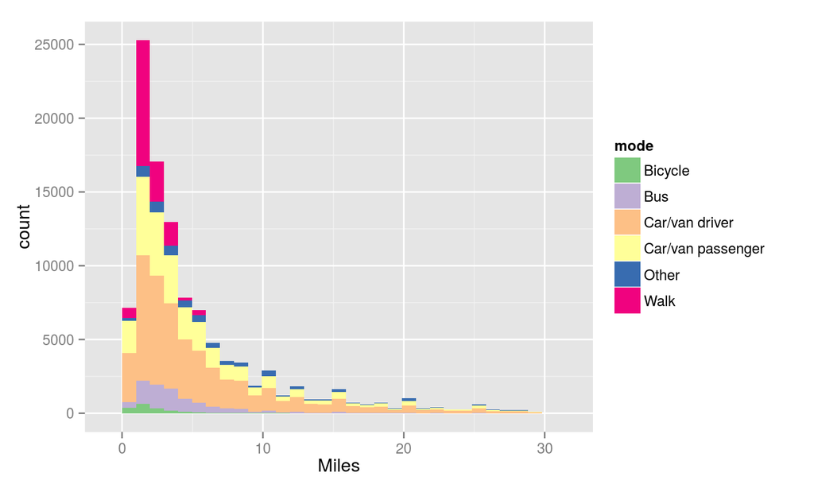

## The simplest case

- In the simplest case, cycling trips double by swapping 1.7% of stages to cycling in every band:

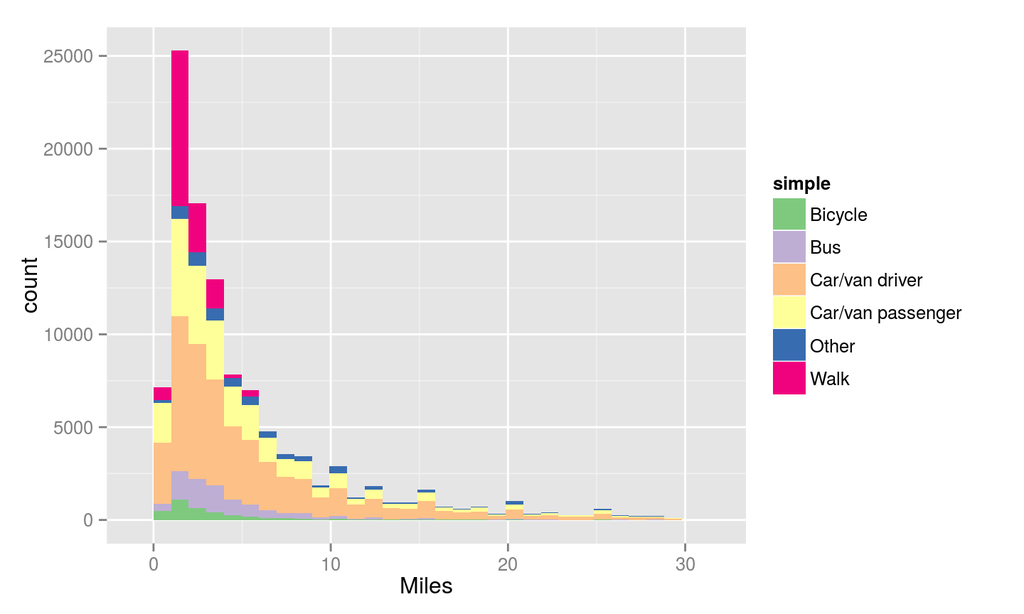

## A close up of cycling

- Distribution of **cycling** stages has grown, shifted to the right:

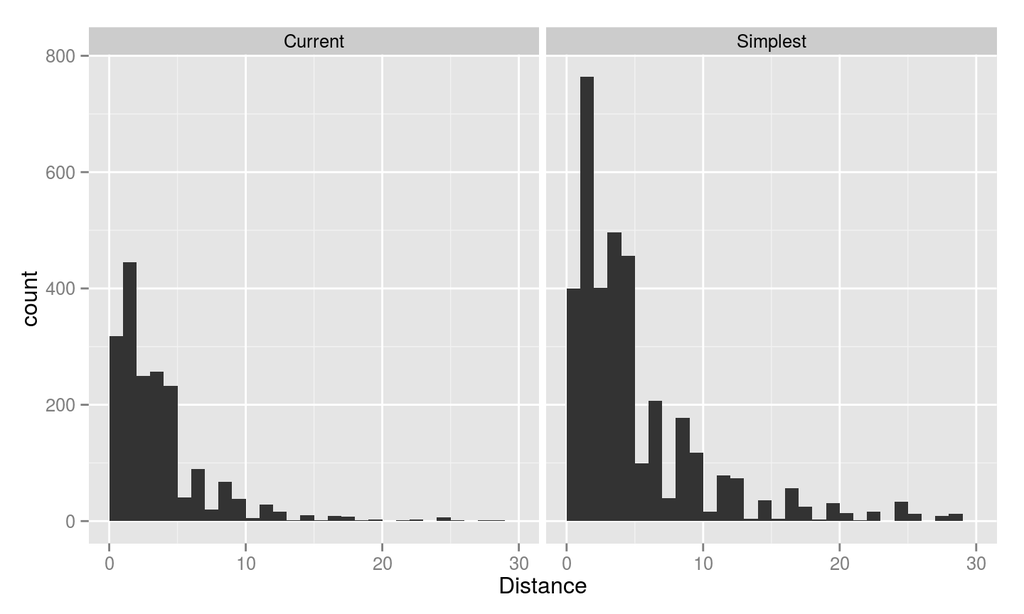

## Incorporating distance

- Simplest example is unrealistically assumes equal proportion of trips shift for every distance band
- In practice it's more like an exponential decay (Iacono et al., 2011)
- Distance can be accounted for by setting probability of a shift as a function of distance

\[p = \alpha e^{-\beta d}\]

## Incorporating distance II

- Values from Iacono et al. (2011) were used: \(\alpha = 0.4\), \(\beta = 0.2\) for bicycle trips
- These parameters can and should be updated with better evidence
- Distance decay, \(\beta\) is dependent on trip purpose, kept constant for now

## Incorporating distance III

- The results look the same as for the simplest scenario yet they are subtly different

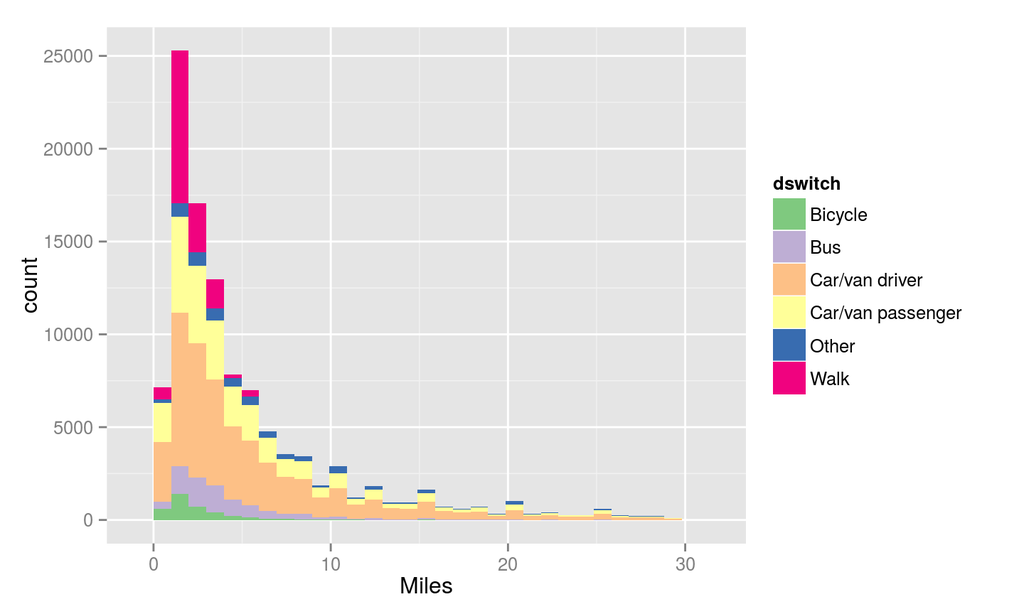

[output not shown]

## Comparing the scenarios II

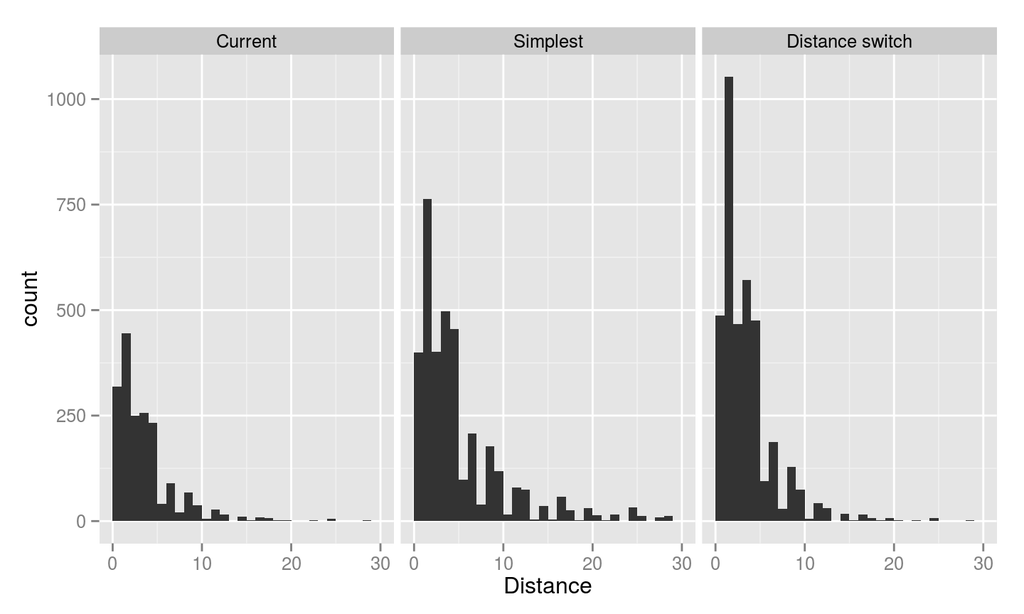

## Including mode of travel

With the per-trip probabilistic modelling framework set-up, driven by prior knowledge of the number/proportion of stages to be made by bicycle, it is easy to refine.

- Evidence suggests bicycle uptake disproportionately replaces walking and bus travel than car journeys
- To include this subtlety, we simply assign a relative weight to each mode of travel, indicating how much more likely it is to be replaced by bicycle trips than the others
- If a car we set at 0.5 and bus at 1, for example, half the number of car journeys, on average, would be replaced by bicycle trips than would bus stages
- The absolute probabilities do not matter, as these are determined by the sample size in R's `sample` function (as long as p < 1)

## Altering mode-specific probabilities

| Bus | Car.d | Car.p | Other | Walk |
| --- | --- | --- | --- | --- |
| 1 | 0.5 | 0.6 | 0.5 | 1 |

- Possible issue of double counting
- Comparison of modes that were replaced by new bicycle trips
- Outcome is policy dependent: e.g. congestion charges
- E.g. cuts to bus services -> more bus journeys replaced

## The impact of mode-specific probabilities:

% trips replaced by bicycle in different scenarios:

|  | Bicycle | Bus | Car/van driver | Car/van passenger | Other | Walk |
| --- | --- | --- | --- | --- | --- | --- |
| Distance | 0 | 6.8 | 42.9 | 25.8 | 3.4 | 21.1 |
| Distance + Modes | 0 | 11.2 | 32.8 | 21.9 | 3.2 | 31 |

- No strong evidence on likely distribution
- Just distance scenarios used at present for 'policy neutrality'

## Including trip purpose

|  | Shopping | Commuting | Visiting.friends | Other | Percent |
| --- | --- | --- | --- | --- | --- |
| All_modes | 18.6 | 17.4 | 16.2 | 47.8 | 100.0 |
| Bicycle | 12.0 | 32.9 | 13.6 | 41.5 | 1.7 |
| Bus | 26.4 | 20.6 | 13.9 | 39.0 | 7.5 |
| Car/van driver | 19.7 | 22.0 | 13.4 | 44.9 | 46.4 |
| Car/van passenger | 17.8 | 6.8 | 23.5 | 51.9 | 25.9 |
| Walk | 16.8 | 11.9 | 13.4 | 57.9 | 12.6 |

- Current preferences may not reflect future change
- Low % could represent aversion to cycling for shopping. Or growth potential…
- Probabilities of switch by purpose is highly policy dependent

## Including socio-demographics

- Not is inclined to cycle, especially in car-dominated settlements with poor cycle infrastructure
- Variability is a function of age: the young have been responsible for most growth in cycling in London and some elderly cannot cycle
- Large implications for health savings
- Strategy: modify probability of switching each stage to bicycle based on the age of the traveller

## Including space

- To take account of space, we subset individuals by region (variable j58g)
- The characteristics of *current* trips in each region will then filter-down into probability of modal shift
- This will provide insight into how high growth rates will have to be in London for nationwide targets to be met

## Trips distributions by region I

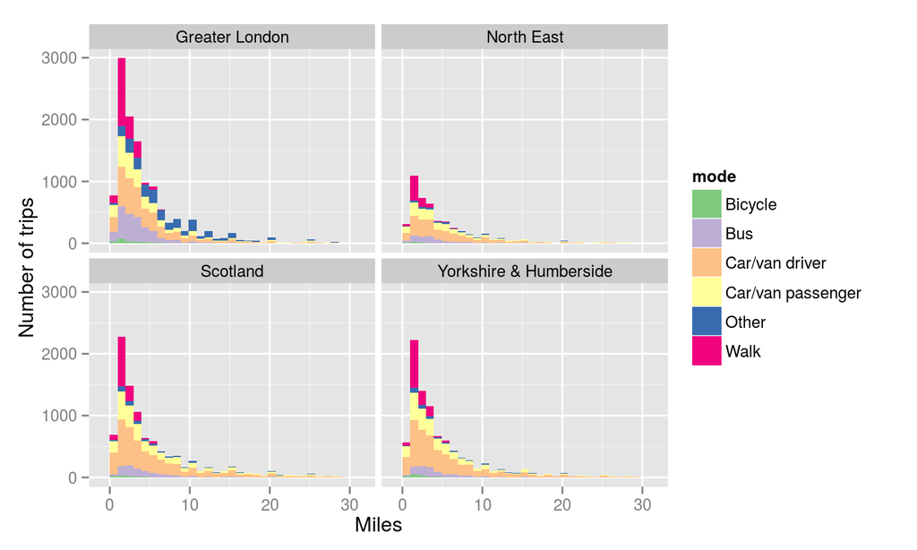

## Trips distributions by region II

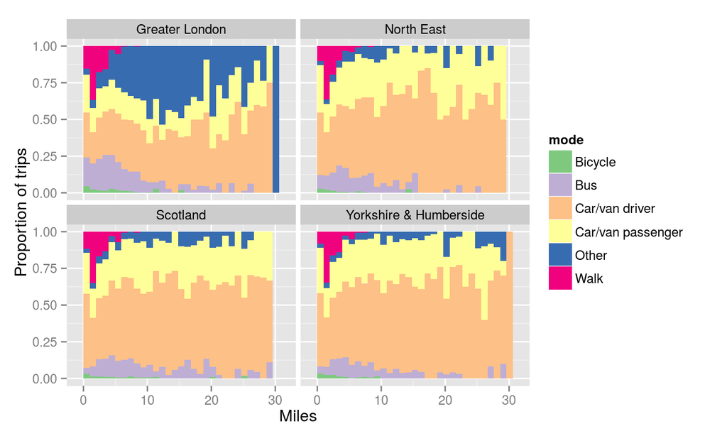

## Energy savings by 2050

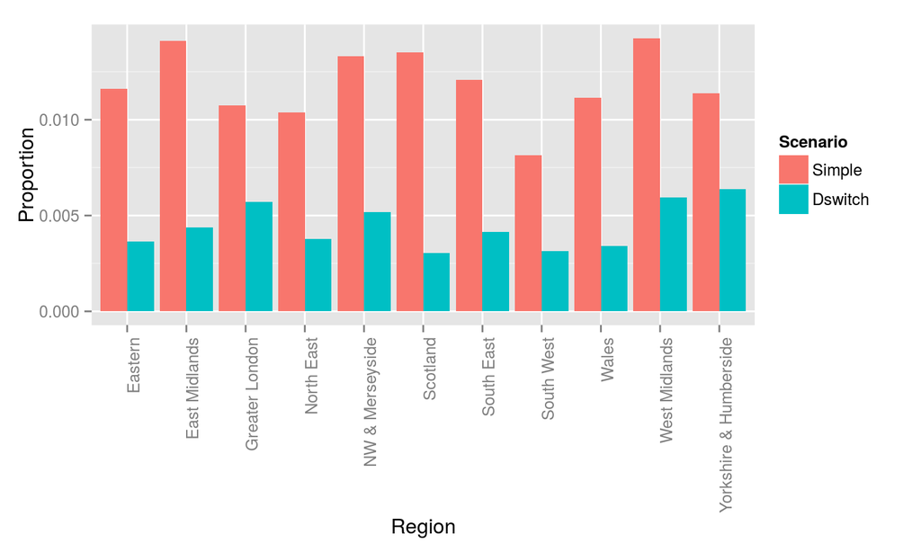

## Discussion and conclusion

- Region -> LA -> individual -> trip -> stage level analysis
- Short-term GBC parliamentary debate, monetary valuation is needed
- Increased physical activity due to cycling will be an output
- Emissions savings: relatively straightforward
- Estimating congestion savings still a challenge
- Mid-term aim: use scenarios to update 2011 work: Energy implications of modal shift to cycling to 2050 in the UK